# Workshop: Plotting with GGPlot and Plotly

#### a. geom_area(): Create an area plot

Manually generate **wdata** by typing in *wdata = data.frame(sex = factor(rep(c(“F”, “M”), each=200)), weight = c(rnorm(200, 55), rnorm(200, 58)))*

```r
set.seed(1234)
wdata = data.frame(
   sex = factor(rep(c("F", "M"), each=200)),
   weight = c(rnorm(200, 55), rnorm(200, 58)))
head(wdata, 4)
```

```
  sex   weight
1   F 53.79293
2   F 55.27743
3   F 56.08444
4   F 52.65430
```

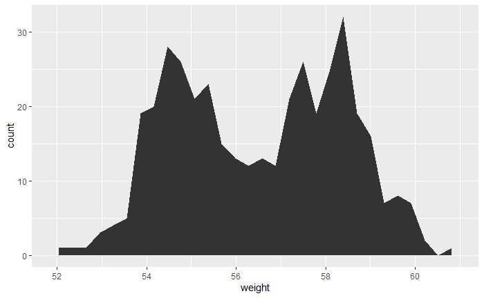

```r
p <- ggplot(wdata, aes(x = weight))
# Basic plot
p + geom_area(stat = "bin")
```

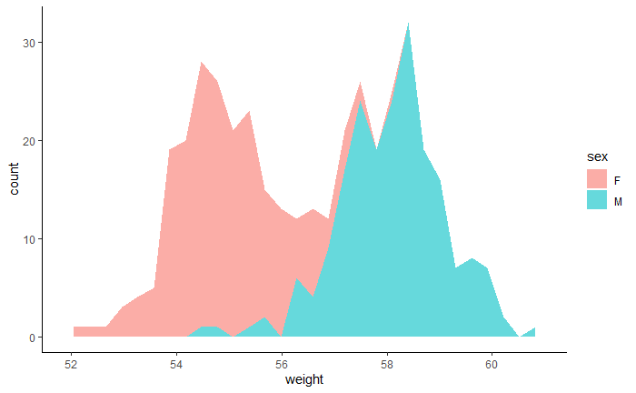

```r
# change fill colors by sex
p + geom_area(aes(fill = sex), stat ="bin", alpha=0.6) +
  theme_classic()
```

#### b. geom_density(): Create a smooth density estimate

Please use the following functions:

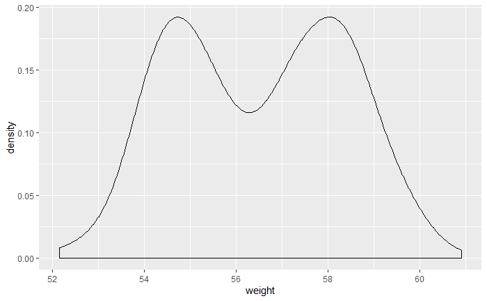

```r
# Basic plot
p + geom_density()
```

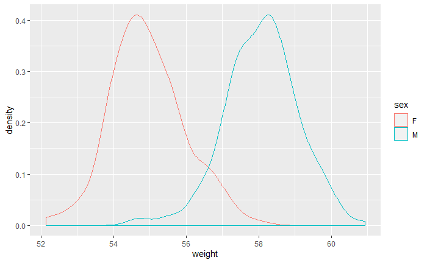

```r
# change line colors by sex
p + geom_density(aes(color = sex))
```

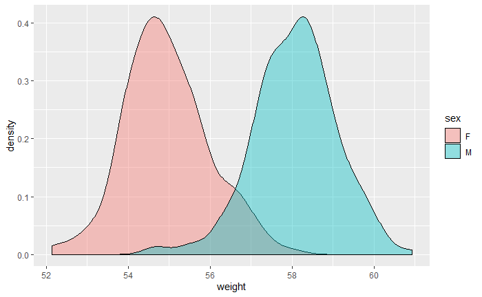

```r
# Change fill color by sex
# Use semi-transparent fill: alpha = 0.4
p + geom_density(aes(fill = sex), alpha=0.4)
```

#### c. geom_histogram(): Histogram

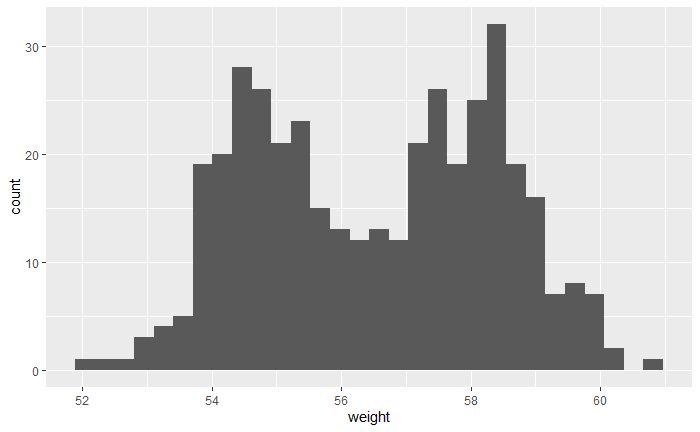

```r
# Basic plot
p + geom_histogram()
```

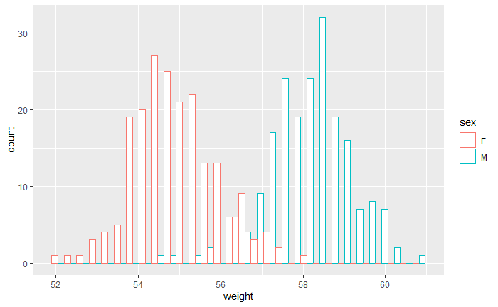

```r
# change line colors by sex
p + geom_histogram(aes(color = sex), fill = "white", position = "dodge")
```

#### d. One variable: Discrete

The function **geom_bar()** can be used to visualize one discrete variable. In this case, the count of each level is plotted. Please use the **mpg** data set [in **ggplot2** package]. The R code is as follow:

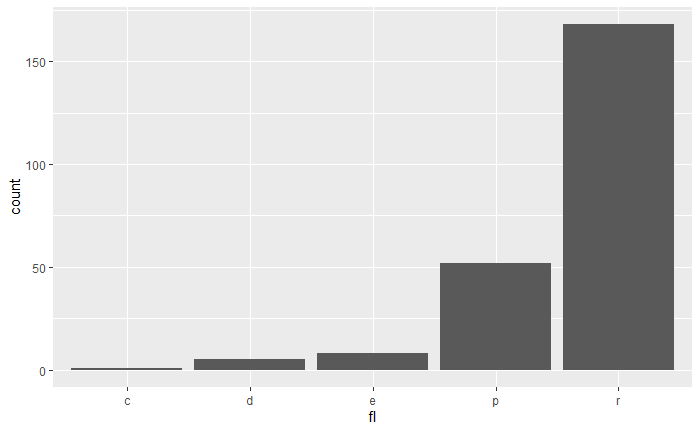

```r
data(mpg)
b <- ggplot(mpg, aes(fl))
# Basic plot
b + geom_bar()
```

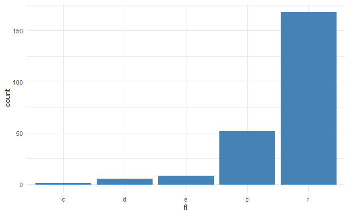

```r
# Change fill color
b + geom_bar(fill = "steelblue", color ="steelblue") +
  theme_minimal()
```

### Ex.5: Box plots

Please use the **ToothGrowth data** set which consists of the continuous variable *len* (for tooth length) by the discrete variable *dose*.

```r
data("ToothGrowth")
ToothGrowth$dose <- as.factor(ToothGrowth$dose)
head(ToothGrowth)
```

```
   len supp dose
1  4.2   VC  0.5
2 11.5   VC  0.5
3  7.3   VC  0.5
4  5.8   VC  0.5
5  6.4   VC  0.5
6 10.0   VC  0.5
```

```r
p <- ggplot(ToothGrowth, aes(x = dose, y = len))
```

Possible layers include:

- **geom_boxplot()** for box plot
- **geom_violin()** for violin plot
- **geom_dotplot()** for dot plot
- **geom_jitter()** for stripchart
- **geom_line()** for line plot
- **geom_bar()** for bar plot

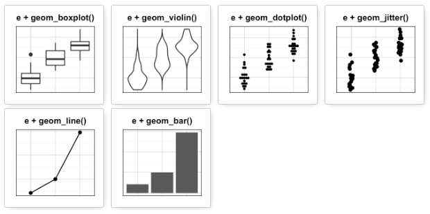

#### a. geom_boxplot(): Box and whiskers plot

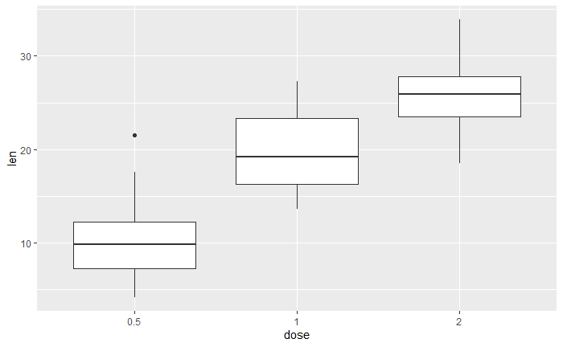

```r
# Default plot
p + geom_boxplot()
```

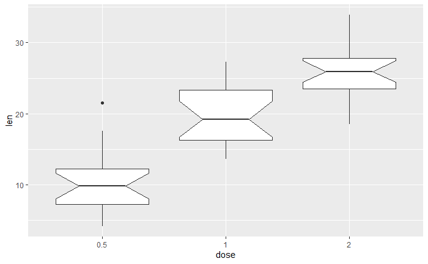

```r
# Notched box plot
p + geom_boxplot(notch = TRUE)
```

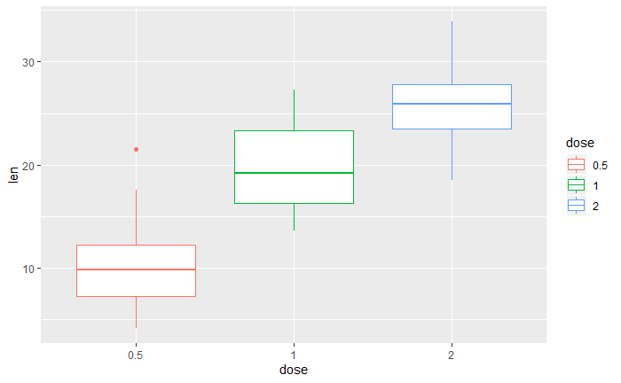

```r
# Color by group (dose)
p + geom_boxplot(aes(color = dose))
```

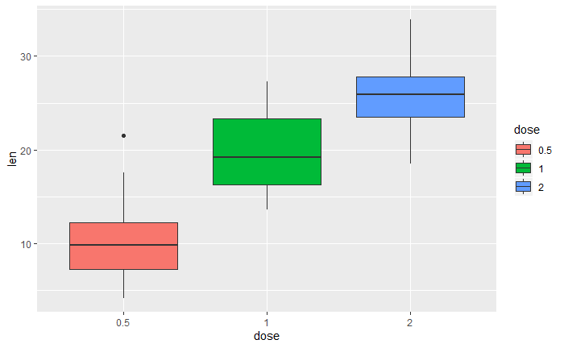

```r
# Change fill color by group (dose)
p + geom_boxplot(aes(fill = dose))
```

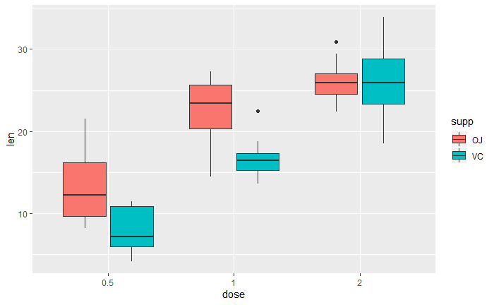

```r
# Box plot with multiple groups
ggplot(ToothGrowth, aes(x=dose, y=len, fill=supp)) + geom_boxplot()
```

#### b. geom_violin(): Violin plot

Violin plots are similar to box plots, except that they also show the kernel probability density of the data at different values.

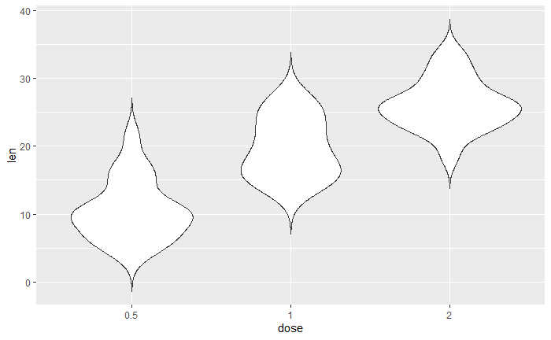

```r
# Default plot
p + geom_violin(trim = FALSE)
```

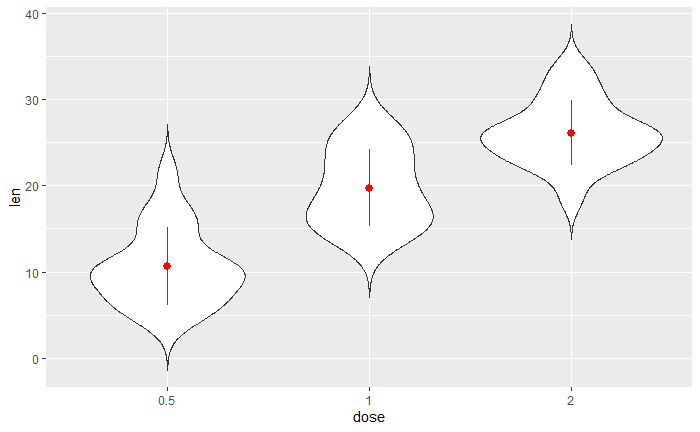

```r
# violin plot with mean points (+/- SD)
p + geom_violin(trim = FALSE) +
  stat_summary(fun.data="mean_sdl",  fun.args = list(mult=1),
               geom="pointrange", color = "red")
```

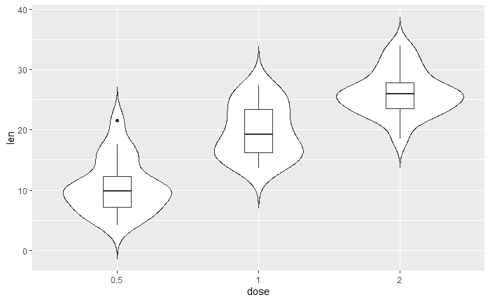

```r
# Combine with box plot
p + geom_violin(trim = FALSE) +
  geom_boxplot(width = 0.2)
```

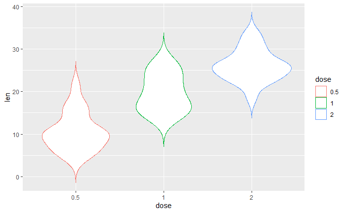

```r
# Color by group (dose)
p + geom_violin(aes(color = dose), trim = FALSE)
```

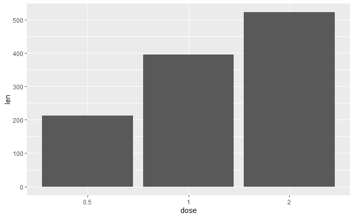

```r
# Basic bar plot
p + geom_bar(stat = "identity")
```

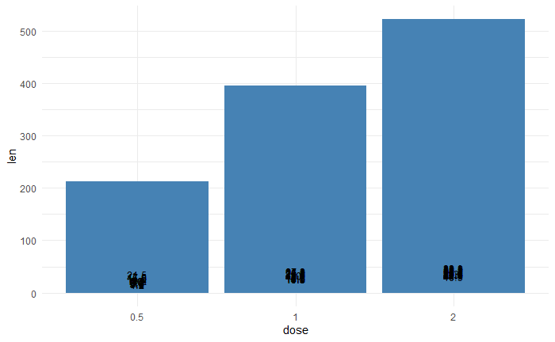

```r
# Change fill color and add labels
p + geom_bar(stat="identity", fill="steelblue")+
  geom_text(aes(label=len), vjust=-0.3, size=3.5)+
  theme_minimal()
```

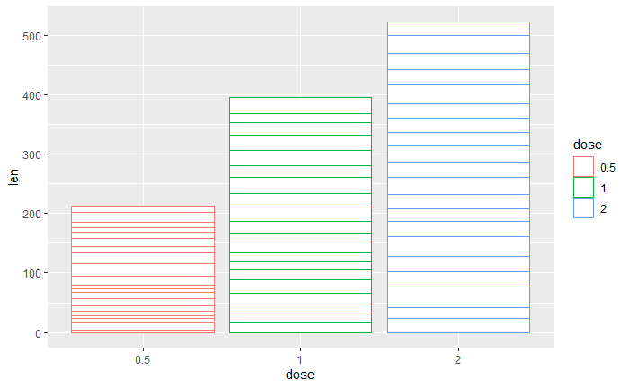

```r
# Change bar plot line colors by groups
p + geom_bar(aes(color = dose),
             stat="identity", fill="white")
```

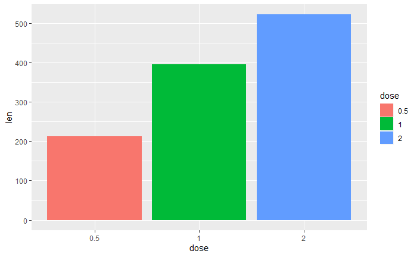

```r
# Change bar plot fill colors by groups
p + geom_bar(aes(fill = dose), stat="identity")
```

Bar plot with multiple groups:

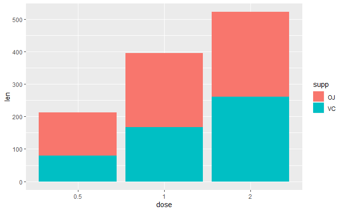

```r
p <- ggplot(data=ToothGrowth, aes(x=dose, y=len, fill=supp))
# Stacked bar plot
p + geom_bar(stat = "identity")
```

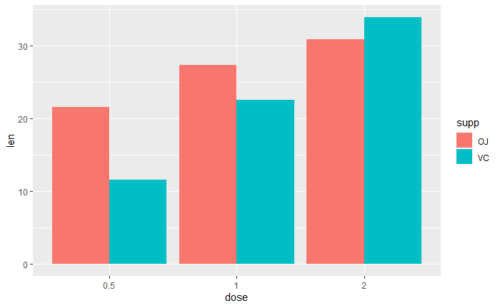

```r
# Use position=position_dodge()
p + geom_bar(stat="identity", position=position_dodge())
```

#### AWESOME Reference: (http://www.sthda.com/english/wiki/be-awesome-in-ggplot2-a-practical-guide-to-be-highly-effective-r-software-and-data-visualization)